# Introduction to ggplot: Basic Visualizers

36-350 – Statistical Computing

Week 6 – Fall 2020

# Preliminaries

Let’s read in a data frame:

```r
df = read.csv("http://www.stat.cmu.edu/~pfreeman/GalaxyMass.csv")
```

These data consist of 3456 rows and 10 columns with names

```r
names(df)
```

```
##  [1] "field"  "Gini"   "M20"    "C"      "A"      "size"   "n"      "q"
##  [9] "z.mode" "mass"
```

# ggplot

`ggplot` (actually, and perhaps confusingly, `ggplot2`) is “a system for declaratively creating graphics, based on The Grammar of Graphics. You provide the data [frame], tell `ggplot2` how to map variables to aesthetics, what graphical primitives to use, and it takes care of the details.”

Sounds good. Let’s dive in:

```r
library(ggplot2)    # also loaded as part of the tidyverse
```

# ggplot: Bar Chart

A very basic call to `ggplot()` has the following structure:

```
ggplot(data=<data frame>,mapping=aes(x=<x axis variable>,...)) + geom_<plot type>(<arguments>)
```

For instance, how many galaxies are in each field?

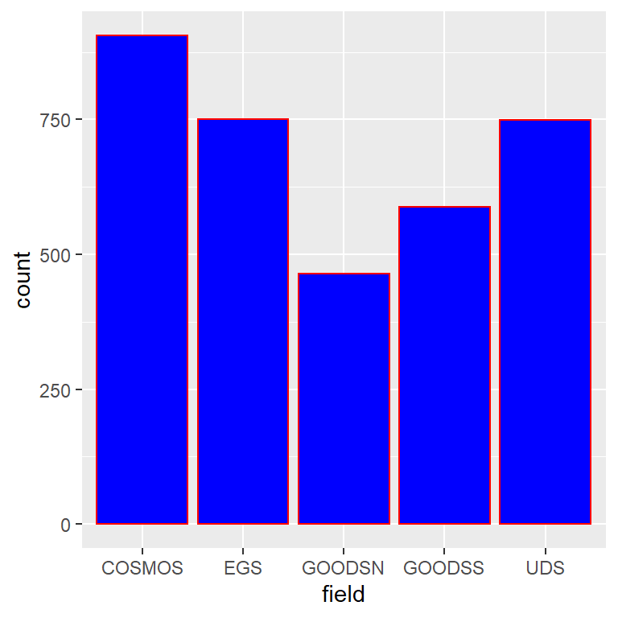

```r
ggplot(data=df,mapping=aes(x=field)) + geom_bar(color="red",fill="blue")
```

(A bar chart is appropriate when the x-axis variable is categorical and the y-axis variable is quantitative.)

# ggplot: Histogram

What is the distribution of galaxy sizes?

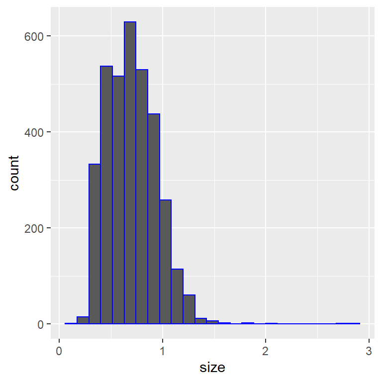

```r
ggplot(data=df,mapping=aes(x=size)) + geom_histogram(color="blue",bins=25)
```

(A histogram is appropriate when the single variable in question is quantitative.)

# ggplot: Boxplot

Boxplots are just a bit trickier. What is the distribution of galaxy concentrations?

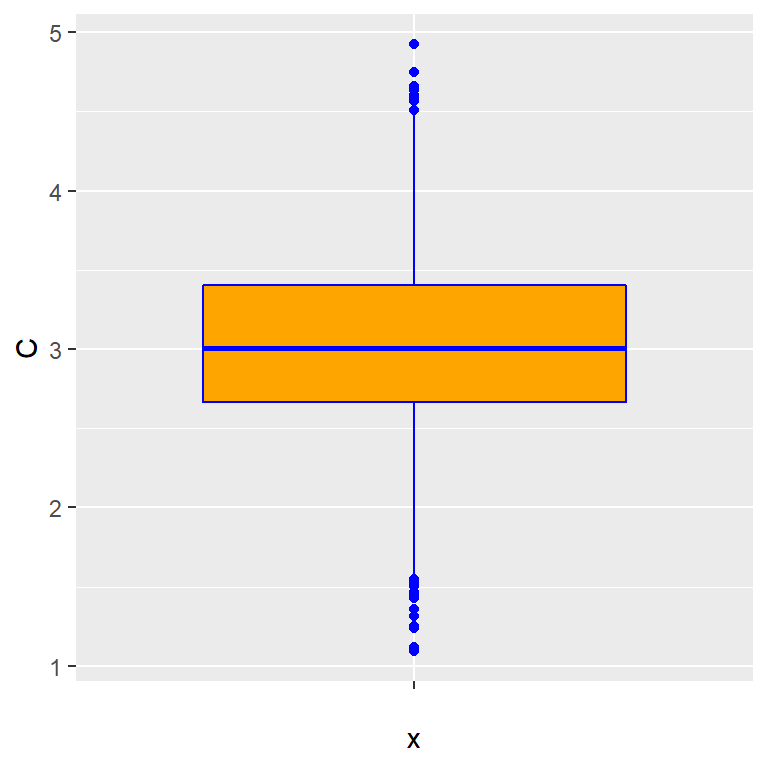

```r
ggplot(data=df,mapping=aes(x="",y=C)) + geom_boxplot(color="blue",fill="orange")
```

(A boxplot is also for visualizing a quantitative variable.)

# ggplot: Faceting

Faceting is the act of making multiple plots at once that appear side-by-side as “facets”. Faceting is something you might want to do when, e.g., you have a factor variable. Here, we show histograms of the concentration variable `C` broken up by galaxy field.

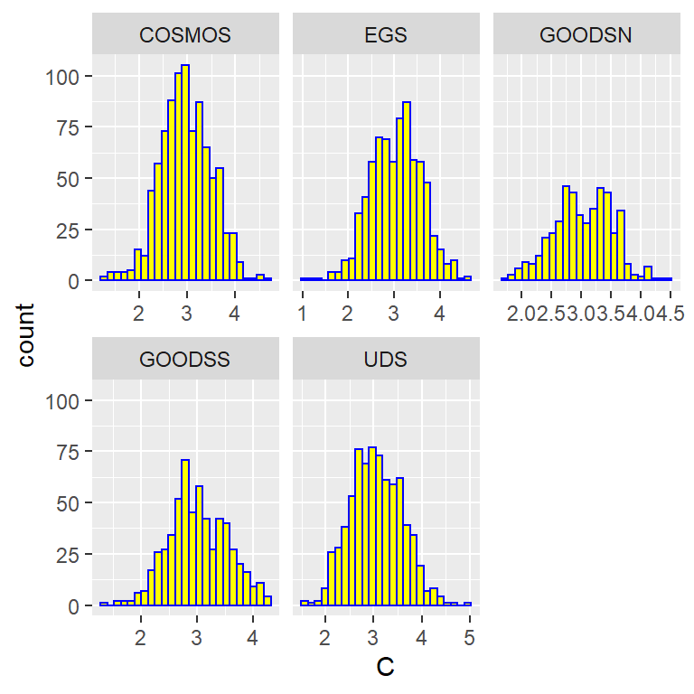

```r
ggplot(data=df,mapping=aes(x=C)) + geom_histogram(color="blue",fill="yellow",bins=25) +
  facet_wrap(~field,scales='free_x')
```

# ggplot: Gather

`gather()` is a function (from the `tidyr` package) that takes a data frame and realigns it. It is best illustrated via a simple example. Let’s say we have the following data frame, which we’ll call `df`:

```
> df
     x   y
1  0.5 0.7
2  1.2 1.9
```

If we “gather” these data, we get the following:

```
> library(tidyr)
...
> gather(df)
      key  value
1       x    0.5
2       x    1.2
3       y    0.7
4       y    1.9
```

Combining `gather()` with faceting allows one to, e.g., visualize multiple variables at once.

# ggplot: Gather (+ dplyr)

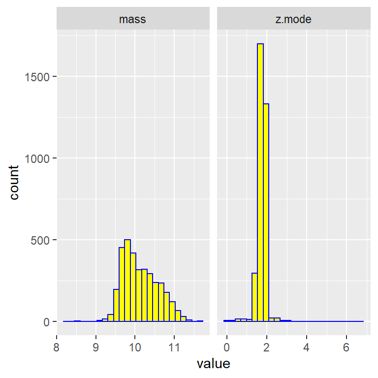

```r
suppressMessages(library(tidyr))
suppressMessages(library(magrittr))
suppressMessages(library(dplyr))

df.new = df %>% select(.,z.mode,mass) %>% gather(.)
ggplot(data=df.new,mapping=aes(x=value)) + geom_histogram(color="blue",fill="yellow",bins=25) +
  facet_wrap(~key,scales='free_x')
```

# ggplot: Scatter Plot

How does the concentration of light in a galaxy vary as a function of its mass?

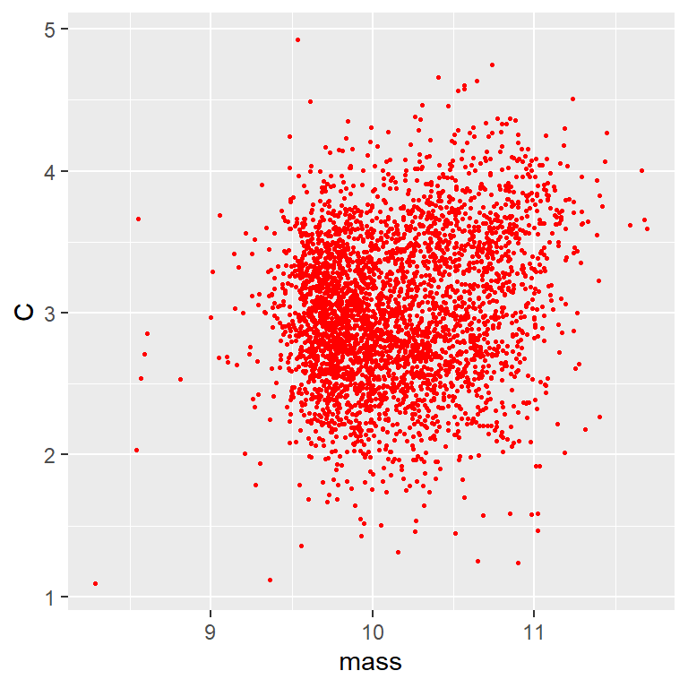

```r
ggplot(data=df,mapping=aes(x=mass,y=C)) + geom_point(color="red",size=0.5)
```

# ggplot: Scatter Plot with Density

By using `geom_density_2d()` we can overlay contours that indicate the density of points:

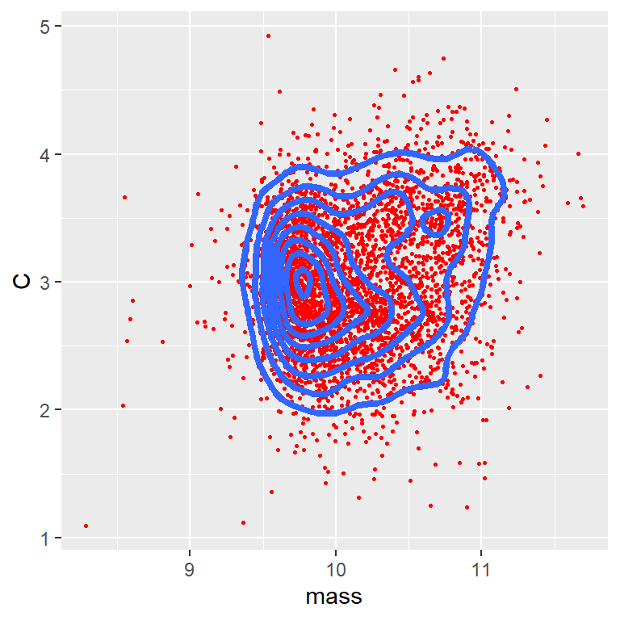

```r
ggplot(data=df,mapping=aes(x=mass,y=C)) + geom_point(color="red",size=0.5) + geom_density_2d(size=1.5)
```

There is an indication here that more massive galaxies more have a bit more concentrated light…but we’d really need to move to methods of statistical learning before saying anything more.